# DataAnalysis

Gabrielle McCabe

20/01/2020

# Read and Manipulate Measurements Data

Import dplyr and ggplot2 and read measurements.csv. This data set has a list of 10 different species, each with a limb width value and limb length value, in either millimeters or centimeters.

```r
library("dplyr")
```

```r
library("ggplot2")
MData <- read.csv("Data/measurements.csv", header = TRUE)
```

Change the column names to shorter, 3-letter abbreviations. Spp: species. LbW: limb width. UtW: units for width. LbL: limb length. UtL: units for length.

```r
MData <- rename(MData, Spp = Organism, LbW = Limb.Width, UtW = unitsW,
                LbL = Limb.Length, UtL = unitsL)
```

Convert all limb width and limb length values to centimetres and save them in 2 new columns (LWc: limb length cm; LLc: limb length cm).

```r
MData$LWc <- MData$LbW
for(i in 1:length(MData$LWc)) {
  if(MData$UtW[i] == "mm") {
    MData$LWc[i] <- MData$LbW[i] / 10
  }
}

MData$LLc <- MData$LbL
for(i in 1:length(MData$LLc)) {
  if(MData$UtL[i] == "mm") {
    MData$LLc[i] <- MData$LbL[i] / 10
  }
}
```

Create new column called Volume that calculates limb volume as:
$$LimbVolume = pi * (width/2)^2 * length$$

```r
MData <- mutate(MData, Volume = pi * (LWc / 2) ^ 2 * LLc)
```

# Plots

Relationship between limb width (cm) and limb length (cm). Using the clean theme for presentations and publications used in the Colautti Lab.

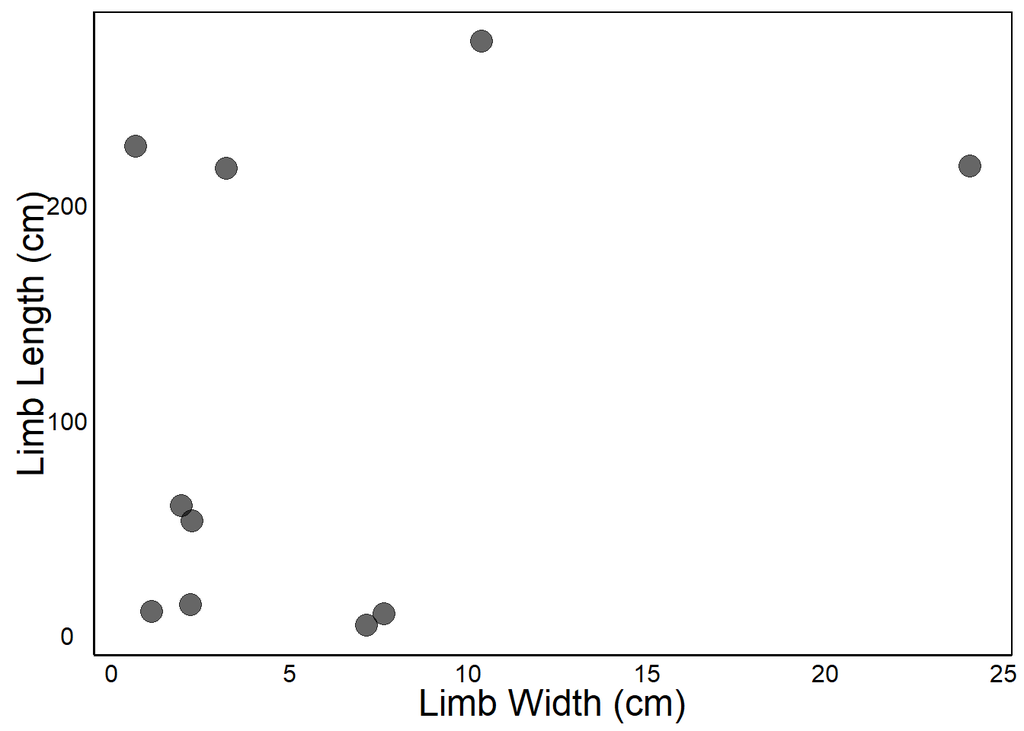

```r
theme_pubworthy <- function (base_size = 12, base_family = "") {
  theme_classic(base_size = base_size, base_family = base_family) %+replace%
    theme(
      axis.text = element_text(colour = "black"),
      axis.title.x = element_text(size=18),
      axis.text.x = element_text(size=12),
      axis.title.y = element_text(size=18,angle=90),
      axis.text.y = element_text(size=12),
      axis.ticks = element_blank(),
      panel.background = element_rect(fill="white"),
      panel.border = element_blank(),
      plot.title=element_text(face="bold", size=24),
      legend.position="none"
    )
}

qplot(x = LWc, y = LLc, data = MData, size = I(5), alpha = I(0.6),
      xlab = "Limb Width (cm)", ylab = "Limb Length (cm)") + theme_pubworthy()
```

Relationship between limb width (cm) and limb length (cm) for species that have above average volume. First, I filtered out the data for species with above average volume, saved it in Above.Avg.Spp and used that data for my plot.

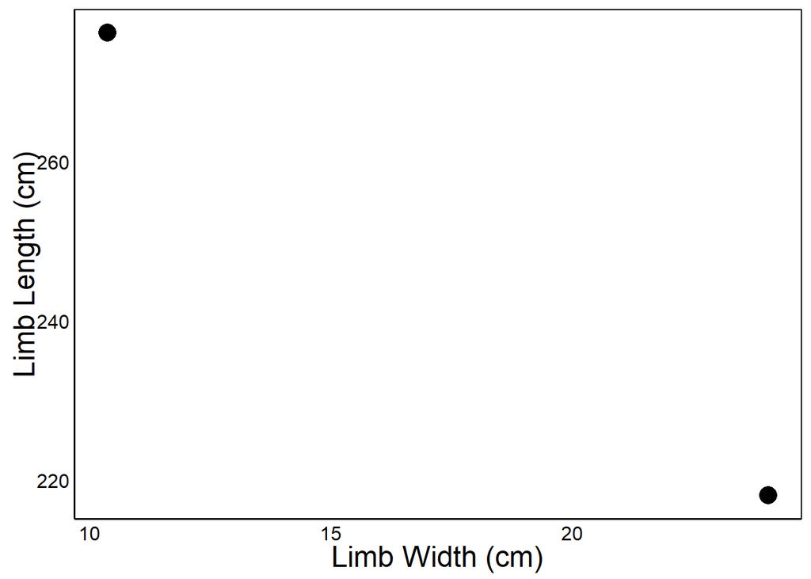

```r
Above.Avg.Spp <- filter(MData, Volume > mean(Volume))

qplot(x = LWc, y = LLc, data = Above.Avg.Spp, size = I(5),
      xlab = "Limb Width (cm)", ylab = "Limb Length (cm)") + theme_pubworthy()
```

# Table 1

First, I filtered out all the species with below average volumes. Then from those species I selected only the Spp and Volume columns and saved that in Below.Avg.Spp. I set echo = T and results = “hide” so that the output of Below.Avg.Spp would not be displayed on the .html but so I could still see it in the .Rmd in order to produce the table below.

```r
Below.Avg.Spp <- MData %>%
  filter(Volume < mean(Volume)) %>%
  select(Spp, Volume)
Below.Avg.Spp
```

This table shows only species and volume for only the species with below-average volume.

| Species | Volume |
| --- | --- |
| Felis catus | 11.28817 |
| Mus musculus | 181.25198 |
| Ateles fusciceps | 54.92002 |
| Bradypus tridactylus | 448.44593 |
| Pterois volitans | 83.73672 |
| Camelus dromedarius | 213.83794 |
| Ornithorhynchus anatinus | 1773.87773 |
| Pongo abelii | 183.27048 |

# Grouping data and Table 2

I added a Habitat column. First, I set the seed so the same random numbers are chosen. Then, I randomly selected 0 and 1 from a binomial distribution and converted 0 to land and 1 to sea.

```r
set.seed(3)
MData <- mutate(MData, Hab = rbinom(10, size = 1, prob = 0.5))

for(i in 1:length(MData$Hab)) {
  if(MData$Hab[i] == "0") {
    MData$Hab[i] <- "land"
  } else {
      MData$Hab[i] <- "sea"
    }
}
```

I Summarized the mean and standard deviation of limb length (cm), limb width (cm), and volume for each of the habitat groups.I set echo = T and results = “hide” so that the output of MData would not be displayed on the .html but so I could still see it in the .Rmd in order to produce the table below.

```r
MData %>%
  group_by(Hab) %>%
  summarise(Mean.Length = mean(LLc), SD.Length = sd(LLc),
            Mean.Width = mean(LWc), SD.Width = sd(LWc),
            Mean.Volume = mean(Volume), SD.Volume = sd(Volume))
```

This table shows the mean and standard deviation (SD) of limb length (cm), limb width (cm), and volume for each of the habitat groups.

| Habitat | Mean Limb Length (cm) | SD Limb Length (cm) | Mean Limb Width (cm) | SD Limb Width (cm) | Mean Volume | SD Volume |
| --- | --- | --- | --- | --- | --- | --- |
| land | 105.6568 | 130.3758 | 4.920396 | 3.925232 | 5125.103 | 10205.79 |
| sea | 112.6543 | 102.7764 | 7.224463 | 9.726004 | 19957.470 | 44256.16 |